# Distributional Consequences of the Clean Energy Transition

Econ 204: Assignment 3

Author

Natalie Smith

```r
library(tidyverse)
library(janitor)
library(here)
library(broom)
library(car)
library(pracma)
```

## 1 1. Linear Regressions and Visualization:

The data set HW3 data.csv provides price (in $) and quantity (in number of EVs) estimates of demand per year for both DAC and non-DAC groups. Run linear regressions (with an intercept) to estimate the demand curves for DAC and non-DAC consumers. What are 2-3 reasons you can think that may explain the differences in demand you estimate?

```r
# Load the data
data <- read.csv("HW3_data.csv") %>%
  janitor::clean_names()
```

```r
# Run linear regressions (with an intercept) to estimate the demand curves for DAC and non-DAC consumers
dac_lm <- lm(price_dollars ~ q_dac, data = data)
dac_coeff <- dac_lm$coefficients

non_dac_lm <- lm(price_dollars ~ q_non_dac, data = data)
non_dac_coeff <- non_dac_lm$coefficients
```

```r
#pivot the data to have all dac and non-dac in one column
data_pivot <- data %>%
  pivot_longer(cols = c(q_dac, q_non_dac), names_to = "group", values_to = "quantity")
```

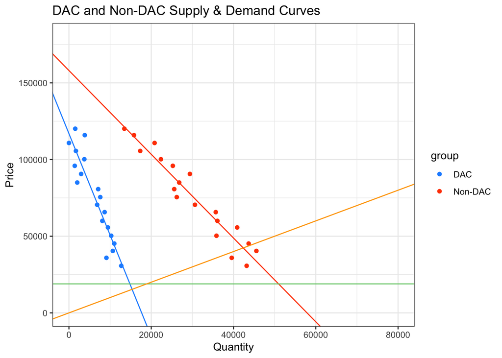

```r
#plot the linear regression for both DAC and non-DAC
ggplot(data_pivot, aes(x = quantity, y = price_dollars)) +
  geom_point(aes(color = group)) +
  labs(title = "DAC and Non-DAC Supply & Demand Curves",
       x = "Quantity",
       y = "Price") +
  geom_abline(aes(intercept = coef(dac_lm)[1], slope = coef(dac_lm)[2]), color = "dodgerblue") +
  geom_abline(aes(intercept = coef(non_dac_lm)[1], slope = coef(non_dac_lm)[2]), color = "orangered1") +
  geom_hline(yintercept = 18900, color = "palegreen3") +  # marginal externality cost line
  geom_abline(intercept = 0, slope = 1, color = "orange") + # supply curve
  scale_color_manual(values = c("dodgerblue", "orangered1"),
                     labels = c("DAC", "Non-DAC")) +
  # scale_linetype_manual(values = c("orange" = "solid", "palegreen3" = "solid"),
  #                       labels = c("Supply", "Marginal Externality Cost")) +
  scale_y_continuous(limits = c(0, 180000)) +
  scale_x_continuous(limits = c(0, 80000)) +
  theme_bw()
```

Reasons that may explain the differences in demand estimates:

- Income: DAC communities might experience lower income levels compared to non-DAC communities, impacting their willingness to pay.
- Education: DAC communities may have lower levels of education compared to non-DAC communities, impacting their familiarity with EV technology.
- Availability of Charging Stations: DAC communities may encounter limited access to charging stations compared to non-DAC communities, potentially influencing their inclination towards EV use.

## 2 2. Marginal Externality Cost:

One kilogram (kg) of lithium is estimated to cause $300 dollars worth of damage in health costs to local communities living near mines. Each EV requires a lithium ion battery containing 63kg of lithium. Assuming there are no other externalities caused by EV production, what is the marginal externality cost per EV produced?

```r
# Define the marginal externality cost per EV produced
MEC <- 300 * 63
```

The marginal externality cost per EV produced is **$18,900**.

## 3 3. Describe the current equilibrium:

### 3.1 a.

What is the aggregate annual demand curve for EVs?

```r
### Write demand functions

### P = a + bQ

dac_demand <- function(Q){
  P = 116854.84 - 6.61*Q
  return(P)
}

nondac_demand <- function(Q){
  P =  158034.28 - 2.73*Q
  return(P)
}

### Q = (P - a)/b

dac_demand_q <- function(P){
  Q = (116854.84 - P)/6.61
  return(Q)
}

nondac_demand_q <- function(P){
  Q = (158034.28 - P)/2.73
  return(Q)
}
```

**DAC Demand:** $P = 116,854.84 - 6.61*Q$

**Non-DAC Demand:** $P = 158,034.28 - 2.73*Q$

```r
### Aggregate demand curve
agg_demand <- function(P) {
  if (P > 116854.84) {
  Q = nondac_demand_q(P)
  }
  if(P <= 116854.84) {
   Q = dac_demand_q(P) + nondac_demand_q(P)
  }
  return(Q)
}
```

**Aggregate demand** $Q = -1.96Q + 148169$

### 3.2 b.

What is the supply curve for EVs?

EVs are currently at a price of $50,000. We can plug this into our aggregate demand equation to find Q:

```r
agg_demand(50000)
```

```
[1] 49687.19
```

```r
### Q = 49687.19

50000/agg_demand(50000)
```

```
[1] 1.006296
```

```r
### 1.006296

supply <- function(Q) {
  P = 0 + 1.006296*Q
  return(P)
}
```

**The supply curve for EVs is: P = 1.006296Q**

```r
# ### P* and Q*
pstar <- 50000
qstar <- agg_demand(50000)
```

### 3.3 c.

What is the “benefit” to consumers under the status quo? difference between the maximum price consumers are willing to pay ($50,000) and the actual price they pay.

```r
### find consumer surplus

cs_fun <- function(a, Q) {
  P = 1/2*(a - 50000)*Q
  return(P)
}

dac_cs <- cs_fun(116854.84, dac_demand_q(50000))
nondac_cs <- cs_fun(158034.28, nondac_demand_q(50000))
cs <- cs_fun(116854.84, dac_demand_q(50000)) + cs_fun(158034.28, nondac_demand_q(50000))

### DAC CS: 338,091,500
### Non-DAC CS: 2,137,620,083
### Total CS: 2,475,711,583
```

**Total Consumer Surplus: 2,475,711,583**

### 3.4 d.

What is the “benefit” to producers under the status quo?

```r
### find producer surplus

ps_fun <- function(Q) {
  P = 1/2*50000*Q
  return(P)
}

ps_fun(agg_demand(50000))
```

```
[1] 1242179825
```

```r
### 1,242,179,825
```

**Producer Surplus: 1,242,179,825**

### 3.5 e.

What is the environmental cost under the status quo?

```r
### EC = MEC* Q
ec <- qstar*MEC
# EC ### 939087948
```

**Environmental Cost: 939,087,948**

```r
# library(ggplot2)
#
# ggplot(data = data_pivot, aes(x = quantity, y = price_dollars, color = group)) +
#   geom_point() +
#     labs(title = "DAC and Non-DAC Supply & Demand Curves",
#        x = "Quantity",
#        y = "Price") +
#   stat_function(fun = function(Q) dac_demand(Q), color = "dodgerblue") +
#   stat_function(fun = function(Q) nondac_demand(Q), color = "orangered1") +
#   stat_function(fun = function(Q) supply(Q), color = "darkgreen") +
#   geom_hline(yintercept = 18900, color = "orange") +
#   scale_color_manual(name = "Group",
#                      values = c("dodgerblue", "orangered1"),
#                      labels = c("DAC", "Non-DAC")) +
#   ylim(0, 190000) +
#   xlim(0, 90000) +
#   theme_minimal()
```

## 4 4. How is the current consumer benefit divided between DAC and non-DAC consumers?

```r
### DAC CS: 338,091,500
### Non-DAC CS: 2,137,620,083

cb_dac <- dac_cs/cs
cb_non_dac <- nondac_cs/cs
```

Current consumer benefit divided between DAC and non-DAC consumers:  
**DAC: 13.67%**  
**Non-DAC: 86.33%**

## 5 5. Optimal EV Tax:

Derive the optimal EV tax (in $ per vehicle) to internalize the lithium mining externality. Noting that recent research has shown that DACs are far more likely to contain mining activity, assume that the mining externality is borne entirely by the DAC group. What would be the effects of this tax on:

### 5.1 a.

The amount of EVs produced and consumed:

**Because MEC is constant, optimal tax = 18,900/EV**

```r
msc <- function(Q) {
  P = MEC + 1.006296*Q
  return(P)
}

msc_q <- function(P) {
  Q = (P - MEC)/1.006296
  return(Q)
}

agg_demand_p <- function(Q){
  P <- -1.96*Q + 148169
  return(P)
}

F3 <- function(Q){
  z <- agg_demand_p(Q) - msc(Q)
  return(z)
}

fzero(F3, c(0,80000))$x
```

```
[1] 43579.27
```

```r
qstar_soc <- 43579.27

#plug in p-star to find the price
p_star_soc <- msc(qstar_soc)
p_star_soc <- 62430.86
```

### 5.2 b.

The price of EVs:

### 5.3 c.

Overall welfare of non-DAC consumers:

```r
cs_non_dac_welfare <- 1/2*(158034.28 - p_star_soc)*nondac_demand_q(p_star_soc)
###  1,673,995,223
# cs_non_dac_welfare
```

**The benefit to non-DAC consumers w/tax = 1,673,995,223.**

### 5.4 d.

Overall welfare of DAC consumers:

```r
cs_dac_welfare <- 1/2*(116854.84 - p_star_soc)*dac_demand_q(p_star_soc)
### 224,052,163
cs_dac_welfare
```

```
[1] 224052163
```

**The benefit to DAC consumers w/tax = 224,052,163.**

### 5.5 e.

EV producers:

```r
# original ps = 1,241,954,750

ps_tax <- 1/2 * (qstar_soc) * (p_star_soc-18900)
# 941,539,757

# ps_tax
```

### 5.6 f.

Total environmental damage:

```r
### Environmental cost = MEC ($18,900) * Qagg(50,000)
env_cost_tax <- 18900 * qstar_soc
# env_cost_tax
# = 817,585,650

#enviro cost (no tax) = 939087948

envirodamage <- ec - env_cost_tax
envirodamage
```

```
[1] 115439745
```

### 5.7 g.

Total tax revenue generated:

```r
tax_revenue <- 817585650
```

## 6 6. Redistributive Effects of the EV Tax:

Now, assume that all revenue from the EV tax will be redistributed to the consumers in proportion to their pre-tax consumption of EVs. For example, if 80% of the EVs were consumed by non-DAC consumers, then they get 80% of the tax revenue. Calculate the effects of this EV tax on:

If pre-tax is 50,000, then:

```r
nondac_demand_q(50000)
```

```
[1] 39573
```

```r
# 39573

dac_demand_q(50000)
```

```
[1] 10114.2
```

```r
#10114.2
```

Non-DAC communities consume 39,573 units, while DAC communities consume 10,114 units. Therefore, **non-DAC** consumers would receive approximately **79%** of the tax revenue, while **DAC** consumers would receive around **21%**.

### 6.1 a.

Overall welfare of non-DAC consumers:

```r
#NONDAC
cs_non_dac_welfare + tax_revenue * 0.79
```

```
[1] 2319887886
```

```r
#2,319,887,886
```

**Overall welfare of non-DAC consumers is 2,319,887,886**

### 6.2 b.

Overall welfare of DAC consumers:

```r
#DAC
cs_dac_welfare + tax_revenue * 0.21
```

```
[1] 395745150
```

```r
#395745150
```

**Overall welfare of DAC consumers is 395,745,150**

## 7 7. Qualitative Analysis:

Based on your findings, use 1-3 sentences to answer the following (qualitatively only):

### 7.1 a.

Are non-DAC consumers likely to support the EV tax? How would the redistribution regime in question #6 affect their support for the tax?

**Non-DAC consumers are unlikely to support the original EV tax since they would bear more of the tax burden. However, with the redistribution regime they would be more likely to support it, especially since they have the higher demand for EVs and do not suffer any damage from the mining externality.**

### 7.2 b.

Are DAC consumers likely to support the EV tax? How would the redistribution regime in question #6 affect their support for the tax?

**DAC consumers are less likely to support the EV tax since they are the ones bearing the environmental cost of lithium mining, dispite having lower demand for EVs. Still, If given the option for no tax, or the tax with redistribution, they would likely support the tax with redistribution as they would receive a portion of the tax revenue.**